# P5-supplemental

## Data Exploration

The number of 'NaN' values for each feature were counted. The 'NaN' values were kept in the dataset as the 'NaN' seems to represent that a feature is not applicable to a person. This can be seen in the insiderpay.pdf document.

A new feature called 'total' was added. This is the sum of the salary, bonus and total_stock_value. There were 18 persons of interest (poi's) out of 146 people. 13% of the data is from poi's (after exluding outliers).

Three values ("Total", "The travel agency in the park", ‘LOCKHART EUGENE E'). "Total" was the total values for the financial data, "The travel agency in the park" was an account for travel expenses and ‘LOCKHART EUGENE E' only has 'NaN' for all features.

In addition, the features will be rescaled before applying the classification algorithms because of the variation in magnitude of the features.

```python
#!/usr/bin/python

import sys
import pickle

path = 'C:\\Users\\Anjali\\Downloads\\ud120-projects-master\\ud120-projects-master\\final_project\\final_project_dataset.pkl'

from feature_format import featureFormat, targetFeatureSplit
from tester import dump_classifier_and_data
import numpy as np
import pandas as pd
import matplotlib.pyplot as plt
from collections import defaultdict

### Task 1: Select what features you'll use.
### features_list is a list of strings, each of which is a feature name.
### The first feature must be "poi".
# Add financial and email features to feature list.
features_list = ['poi','salary', 'deferral_payments', 'total_payments', 'loan_advances',
                 'bonus', 'restricted_stock_deferred', 'deferred_income', 'total_stock_value',
                 'expenses', 'exercised_stock_options', 'other', 'long_term_incentive',
                 'restricted_stock', 'director_fees', 'to_messages', 'from_poi_to_this_person',
                 'from_messages', 'from_this_person_to_poi', 'shared_receipt_with_poi']
print "Number of features", len(features_list[1:])

### Load the dictionary containing the dataset
with open(path, "r") as data_file:
    data_dict = pickle.load(data_file)
print "Number of data points", len(data_dict)
### Task 2: Remove outliers
# Remove 'TOTAL' and THE TRAVEL AGENCY IN THE PARK' as these are not employees.
# Remove 'LOCKHART EUGENE E' as there are only 'NaN' values associated with employee.
print data_dict['LOCKHART EUGENE E']
del data_dict['TOTAL']
del data_dict['THE TRAVEL AGENCY IN THE PARK']
del data_dict['LOCKHART EUGENE E']
# Create new feature that is sum of salary, bonus, total, stock value
# Use feature_nan to count NaN values
new_feature = ['salary','bonus', 'total_stock_value']
feature_nan = defaultdict(int)
for name, info in data_dict.iteritems():

    total = 0
    for feat, val in info.iteritems():
        if val == 'NaN':
            feature_nan[feat] += 1
        if feat in new_feature and val != 'NaN':
            total += val
    data_dict[name]['total'] = total

for key, value in feature_nan.iteritems():
    print key, value

### Store to my_dataset for easy export below.
my_dataset = data_dict
features_list.append('total')

### Extract features and labels from dataset for local testing
data = featureFormat(my_dataset, features_list, sort_keys = True)
labels, features = targetFeatureSplit(data)

# Create dataframe of data for exploration
features_df = pd.DataFrame(features, columns = features_list[1:])
poi_df = pd.DataFrame(labels, columns = ['poi'])
features_poi_df = pd.concat([features_df, poi_df], axis = 1)

#Count of all poi
print "Number of poi's:", features_poi_df.poi.sum()
print features_poi_df.count()
```

```
Number of features 19
Number of data points 146
{'salary': 'NaN', 'to_messages': 'NaN', 'deferral_payments': 'NaN', 'total_payments': 'NaN', 'exercised_stock_options': 'NaN', 'bonus': 'NaN', 'restricted_stock': 'NaN', 'shared_receipt_with_poi': 'NaN', 'restricted_stock_deferred': 'NaN', 'total_stock_value': 'NaN', 'expenses': 'NaN', 'loan_advance…
salary 49
to_messages 57
deferral_payments 105
total_payments 20
long_term_incentive 78
loan_advances 140
bonus 62
restricted_stock 34
restricted_stock_deferred 126
total_stock_value 18
shared_receipt_with_poi 57
from_poi_to_this_person 57
exercised_stock_options 42
from_messages 57
other 52
from_this_person_to_poi 57
deferred_income 95
expenses 49
email_address 32
director_fees 127
Number of poi's: 18.0
salary                       143
deferral_payments            143
total_payments               143
loan_advances                143
bonus                        143
restricted_stock_deferred    143
deferred_income              143
total_stock_value            143
expenses                     143
exercised_stock_options      143
other                        143
long_term_incentive          143
restricted_stock             143
director_fees                143
to_messages                  143
from_poi_to_this_person      143
from_messages                143
from_this_person_to_poi      143
shared_receipt_with_poi      143
total                        143
poi                          143
dtype: int64
```

```python
features_poi_df.describe()
```

|  | salary | deferral_payments | total_payments | loan_advances | bonus | restricted_stock_deferred | deferred_income | total_stock_value | expenses | exercised_stock_options | ... | long_term_incentive | restricted_stock | director_fees | to_messages | from_poi_to_this_person | from_messages | from_this_person_to_poi | shared_receipt_with_poi | total | poi |
| --- | --- | --- | --- | --- | --- | --- | --- | --- | --- | --- | --- | --- | --- | --- | --- | --- | --- | --- | --- | --- | --- |
| count | 1.430000e+02 | 1.430000e+02 | 1.430000e+02 | 1.430000e+02 | 1.430000e+02 | 1.430000e+02 | 1.430000e+02 | 1.430000e+02 | 143.000000 | 1.430000e+02 | ... | 1.430000e+02 | 1.430000e+02 | 143.000000 | 143.000000 | 143.000000 | 143.000000 | 143.000000 | 143.000000 | 1.430000e+02 | 143.000000 |
| mean | 1.867429e+05 | 2.236426e+05 | 2.272323e+06 | 5.868881e+05 | 6.807246e+05 | 7.393131e+04 | -1.950377e+05 | 2.930134e+06 | 35622.720280 | 2.090318e+06 | ... | 3.393142e+05 | 8.746100e+05 | 10050.111888 | 1247.216783 | 39.027972 | 366.125874 | 24.797203 | 707.524476 | 3.797601e+06 | 0.125874 |
| std | 1.971171e+05 | 7.565208e+05 | 8.876252e+06 | 6.818177e+06 | 1.236180e+06 | 1.306545e+06 | 6.079225e+05 | 6.205937e+06 | 45370.869604 | 4.809193e+06 | ... | 6.890139e+05 | 2.022338e+06 | 31399.349067 | 2243.006069 | 74.466359 | 1455.452279 | 80.031821 | 1079.457016 | 6.981349e+06 | 0.332873 |
| min | 0.000000e+00 | -1.025000e+05 | 0.000000e+00 | 0.000000e+00 | 0.000000e+00 | -1.787380e+06 | -3.504386e+06 | -4.409300e+04 | 0.000000 | 0.000000e+00 | ... | 0.000000e+00 | -2.604490e+06 | 0.000000 | 0.000000 | 0.000000 | 0.000000 | 0.000000 | 0.000000 | -4.409300e+04 | 0.000000 |
| 25% | 0.000000e+00 | 0.000000e+00 | 9.679650e+04 | 0.000000e+00 | 0.000000e+00 | 0.000000e+00 | -3.750600e+04 | 2.549360e+05 | 0.000000 | 0.000000e+00 | ... | 0.000000e+00 | 3.827650e+04 | 0.000000 | 0.000000 | 0.000000 | 0.000000 | 0.000000 | 0.000000 | 6.322470e+05 | 0.000000 |
| 50% | 2.106920e+05 | 0.000000e+00 | 9.665220e+05 | 0.000000e+00 | 3.000000e+05 | 0.000000e+00 | 0.000000e+00 | 9.760370e+05 | 21530.000000 | 6.087500e+05 | ... | 0.000000e+00 | 3.605280e+05 | 0.000000 | 383.000000 | 4.000000 | 18.000000 | 0.000000 | 114.000000 | 1.691366e+06 | 0.000000 |
| 75% | 2.702590e+05 | 9.110000e+03 | 1.956978e+06 | 0.000000e+00 | 8.000000e+05 | 0.000000e+00 | 0.000000e+00 | 2.307584e+06 | 53534.500000 | 1.698900e+06 | ... | 3.748255e+05 | 7.759920e+05 | 0.000000 | 1639.000000 | 41.500000 | 54.000000 | 14.000000 | 967.500000 | 3.917918e+06 | 0.000000 |
| max | 1.111258e+06 | 6.426990e+06 | 1.035598e+08 | 8.152500e+07 | 8.000000e+06 | 1.545629e+07 | 0.000000e+00 | 4.911008e+07 | 228763.000000 | 3.434838e+07 | ... | 5.145434e+06 | 1.476169e+07 | 137864.000000 | 15149.000000 | 528.000000 | 14368.000000 | 609.000000 | 5521.000000 | 5.718240e+07 | 1.000000 |

8 rows × 21 columns

## Gaussian Naive Bayes

The data was first classified using Gaussian Naive Bayes. The features were scaled and selected using SelectKBest. The evaluation metrics from the tester script are below:

Accuracy: 0.84780 Precision: 0.41184 Recall: 0.33050

```python
#!/usr/bin/python

import sys
import pickle

path = 'C:\\Users\\Anjali\\Downloads\\ud120-projects-master\\ud120-projects-master\\final_project\\final_project_dataset.pkl'

from feature_format import featureFormat, targetFeatureSplit
from tester import dump_classifier_and_data
from sklearn.preprocessing import MinMaxScaler
from sklearn.feature_selection import SelectKBest
from sklearn.naive_bayes import GaussianNB
from sklearn.metrics import accuracy_score
from sklearn.metrics import precision_score
from sklearn.metrics import recall_score
from sklearn.model_selection import GridSearchCV, StratifiedShuffleSplit
from sklearn.pipeline import Pipeline, make_pipeline

### Task 1: Select what features you'll use.
### features_list is a list of strings, each of which is a feature name.
### The first feature must be "poi".

features_list = ['poi','salary', 'deferral_payments', 'total_payments', 'loan_advances',
                 'bonus', 'restricted_stock_deferred', 'deferred_income', 'total_stock_value',
                 'expenses', 'exercised_stock_options', 'other', 'long_term_incentive',
                 'restricted_stock', 'director_fees', 'to_messages', 'from_poi_to_this_person',
                 'from_messages', 'from_this_person_to_poi', 'shared_receipt_with_poi']
# You will need to use more features

### Load the dictionary containing the dataset
with open(path, "r") as data_file:
    data_dict = pickle.load(data_file)

### Task 2: Remove outliers

del data_dict['TOTAL']
del data_dict['THE TRAVEL AGENCY IN THE PARK']
del data_dict['LOCKHART EUGENE E']

### Task 3: Create new feature(s)
new_feature = ['salary','bonus', 'total_stock_value']
for name, info in data_dict.iteritems():

    total = 0
    for feat, val in info.iteritems():

        if feat in new_feature and val != 'NaN':
            total += val
    data_dict[name]['total'] = total

### Store to my_dataset for easy export below.
my_dataset = data_dict
features_list.append('total')

### Extract features and labels from dataset for local testing
data = featureFormat(my_dataset, features_list, sort_keys = True)
labels, features = targetFeatureSplit(data)

#Scale features, select features and create pipeline

my_pipeline = make_pipeline(MinMaxScaler(), SelectKBest(), GaussianNB())

param_grid = dict(selectkbest__k = [3, 5, 7, 10, 12])
sss= StratifiedShuffleSplit(n_splits= 100, test_size= 0.1, random_state= 42)
grid_search = GridSearchCV(my_pipeline, param_grid, scoring = 'f1', cv = sss)

# Fit to data and find accuracy, precision and recall scores.
grid_search.fit(features, labels)
clf = grid_search.best_estimator_

# Predict on features. Find accuracy, precision and recall.
pred = clf.predict(features)
print accuracy_score(labels, pred)
print precision_score(labels, pred)
print recall_score(labels,pred)



dump_classifier_and_data(clf, my_dataset, features_list)
```

```
0.86013986014
0.428571428571
0.333333333333
```

## Support Vector classifier

The data was next classified using a Support Vector Classifier. The features were scaled and selected using SelectKBest. The evaluation metrics from the tester script are below:

Accuracy: 0.72453 Precision: 0.26986 Recall: 0.62500

```python
#!/usr/bin/python

import sys
import pickle
#sys.path.append("../tools/")
path = 'C:\\Users\\Anjali\\Downloads\\ud120-projects-master\\ud120-projects-master\\final_project\\final_project_dataset.pkl'

from feature_format import featureFormat, targetFeatureSplit
from tester import dump_classifier_and_data

from sklearn.preprocessing import MinMaxScaler
from sklearn.feature_selection import SelectKBest
from sklearn.metrics import accuracy_score
from sklearn.metrics import precision_score
from sklearn.metrics import recall_score
from sklearn.model_selection import GridSearchCV, StratifiedShuffleSplit
from sklearn.svm import SVC


### Task 1: Select what features you'll use.
### features_list is a list of strings, each of which is a feature name.
### The first feature must be "poi".

features_list = ['poi','salary', 'deferral_payments', 'total_payments', 'loan_advances',
                 'bonus', 'restricted_stock_deferred', 'deferred_income', 'total_stock_value',
                 'expenses', 'exercised_stock_options', 'other', 'long_term_incentive',
                 'restricted_stock', 'director_fees', 'to_messages', 'from_poi_to_this_person',
                 'from_messages', 'from_this_person_to_poi', 'shared_receipt_with_poi']
# You will need to use more features

### Load the dictionary containing the dataset
with open(path, "r") as data_file:
    data_dict = pickle.load(data_file)

### Task 2: Remove outliers

del data_dict['TOTAL']
del data_dict['THE TRAVEL AGENCY IN THE PARK']
del data_dict['LOCKHART EUGENE E']

### Task 3: Create new feature(s)
new_feature = ['salary','bonus', 'total_stock_value']
for name, info in data_dict.iteritems():

    total = 0
    for feat, val in info.iteritems():

        if feat in new_feature and val != 'NaN':
            total += val
    data_dict[name]['total'] = total

### Store to my_dataset for easy export below.
my_dataset = data_dict
features_list.append('total')

### Extract features and labels from dataset for local testing
data = featureFormat(my_dataset, features_list, sort_keys = True)
labels, features = targetFeatureSplit(data)

# Scale features, select features, use Support Vector classifier. Create pipeline
my_pipeline = make_pipeline(MinMaxScaler(), SelectKBest(), SVC())
my_pipeline.get_params().keys()

param_grid = dict(selectkbest__k = [3, 5, 7, 10, 12], \
                           svc__C = [1e3, 5e3, 1e4, 5e4, 1e5], \
                           svc__gamma = [0.0001, 0.0005, 0.001, 0.005, 0.01, 0.1], \
                           svc__kernel = ['rbf'], svc__class_weight = ['balanced'])

sss= StratifiedShuffleSplit(n_splits= 100, test_size= 0.1, random_state= 42)
grid_search = GridSearchCV(my_pipeline, param_grid, scoring = 'f1', cv = sss)

#Fit to data, find evaluation metrics.
grid_search.fit(features, labels)
clf = grid_search.best_estimator_
pred = clf.predict(features)
print accuracy_score(labels, pred)
print precision_score(labels, pred)
print recall_score(labels,pred)


dump_classifier_and_data(clf, my_dataset, features_list)
```

```
0.762237762238
0.309523809524
0.722222222222
```

## Decision Tree Classifier

The data was next classified using a Decision Tree Classifier. The features were scaled and selected using SelectKBest. The evaluation metrics from the tester script are below. This classifier has the highest accuracy and precision.

Accuracy: 0.86973 Precision: 0.51285 Recall: 0.45900

```python
#!/usr/bin/python

import sys
import pickle

#sys.path.append("../tools/")
path = 'C:\\Users\\Anjali\\Downloads\\ud120-projects-master\\ud120-projects-master\\final_project\\final_project_dataset.pkl'

from feature_format import featureFormat, targetFeatureSplit
from tester import dump_classifier_and_data

from sklearn.preprocessing import MinMaxScaler
from sklearn.feature_selection import SelectKBest
from sklearn.metrics import accuracy_score
from sklearn.metrics import precision_score
from sklearn.metrics import recall_score
from sklearn.model_selection import GridSearchCV, StratifiedShuffleSplit
from sklearn.tree import DecisionTreeClassifier
from sklearn.pipeline import Pipeline, make_pipeline

### Task 1: Select what features you'll use.
### features_list is a list of strings, each of which is a feature name.
### The first feature must be "poi".

# Combine financial and email features
features_list = ['poi','salary', 'deferral_payments', 'total_payments', \
                'loan_advances', 'bonus', 'restricted_stock_deferred', \
                'deferred_income', 'total_stock_value', 'expenses', \
                'exercised_stock_options', 'other', 'long_term_incentive', \
                 'restricted_stock', 'director_fees', 'to_messages', \
                 'from_poi_to_this_person', 'from_messages', \
                 'from_this_person_to_poi', 'shared_receipt_with_poi']
# You will need to use more features

### Load the dictionary containing the dataset
with open(path, "r") as data_file:
    data_dict = pickle.load(data_file)

### Task 2: Remove outliers
# Remove 'TOTAL' and 'THE TRAVEL AGENCY IN THE PARK' entries.
del data_dict['TOTAL']
del data_dict['THE TRAVEL AGENCY IN THE PARK']
del data_dict['LOCKHART EUGENE E']

### Task 3: Create new feature(s)
# New feature combines salary, bonus and total_stock_value. Add new feature
# to data_dict.
new_feature = ['salary','bonus', 'total_stock_value']
for name, info in data_dict.iteritems():
    total = 0
    for feat, val in info.iteritems():

        if feat in new_feature and val != 'NaN':
            total += val
    data_dict[name]['total'] = total

### Store to my_dataset for easy export below.
# Add new feature to features_list.
my_dataset = data_dict
features_list.append('total')

### Extract features and labels from dataset for local testing
data = featureFormat(my_dataset, features_list, sort_keys = True)
labels, features = targetFeatureSplit(data)

#Create pipeline and parameters with MinMaxScaler, SelectKBest,
#DecisionTreeClassifier
my_pipeline = make_pipeline(MinMaxScaler(), SelectKBest(), \
              DecisionTreeClassifier())
param_grid = dict(selectkbest__k = range(1,15), \
             decisiontreeclassifier__criterion = ['gini', 'entropy'], \
             decisiontreeclassifier__min_samples_split = range(2,20))

#Use StratifiedShuffleSplit for cross validation. Use GridSearchCV to find
#best classifier. Set scoring to f1.
sss= StratifiedShuffleSplit(n_splits= 100, test_size= 0.1, random_state= 42)
grid_search = GridSearchCV(my_pipeline, param_grid, scoring = 'f1', cv = sss)

#Fit to features and labels and return best estimator.
grid_search.fit(features, labels)
clf = grid_search.best_estimator_

# Predict on features. Find accuracy, precision and recall.
pred = clf.predict(features)
print accuracy_score(labels, pred)
print precision_score(labels, pred)
print recall_score(labels,pred)

dump_classifier_and_data(clf, my_dataset, features_list)
```

```
0.972027972028
1.0
0.777777777778
```

## Exploration of Selected Features

The selected features from the selectkbest and decision tree classifier pipeline were further explored. The selected feature distributions were plotted. Outliers are present in each distribution. However, additional outliers will not be removed because only 13% of the data is associated with persons of interest. Excessive removal of outliers could results in incorrect predictions.

```python
from itertools import compress

# Obtain features selected from pipeline
support = grid_search.best_estimator_.named_steps['selectkbest'].get_support()
selected_features = list(compress(features_list[1:], support))
print selected_features

# Obtain feature scores.
scores = grid_search.best_estimator_.named_steps['selectkbest'].scores_

selected_features_scores = list(compress(scores, support))
print selected_features_scores
```

```
['salary', 'bonus', 'total_stock_value', 'exercised_stock_options', 'total']
[18.289684043404513, 20.792252047181538, 24.182898678566872, 24.815079733218194, 29.024830672188315]
```

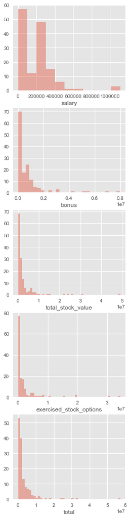

```python
# Graph selected features.
import seaborn as sns
import matplotlib.pyplot as plt
%pylab inline
matplotlib.style.use('ggplot')

#Use pandas dataframe for graphing
features_financial = features_poi_df.loc[0:,'salary':'director_fees']
features_financial = pd.concat([features_financial, poi_df], axis = 1)
features_financial = pd.concat((features_financial, features_poi_df[ 'total']), \
                               axis = 1, join = 'inner')

# Graph distributions of features
fig, axes = plt.subplots(nrows=5, ncols=1, figsize=(4,18))

for i, ax in enumerate(axes.flatten()):

    sns.distplot(features_financial.loc[:, selected_features[i]], kde= False,ax=ax)
```

## Tester

The tester function below was provided to test each classifier algorithm.

```python
#!/usr/bin/pickle

""" a basic script for importing student's POI identifier,
    and checking the results that they get from it

    requires that the algorithm, dataset, and features list
    be written to my_classifier.pkl, my_dataset.pkl, and
    my_feature_list.pkl, respectively

    that process should happen at the end of poi_id.py
"""

import pickle
import sys
from sklearn.cross_validation import StratifiedShuffleSplit
#sys.path.append("../tools/")
from feature_format import featureFormat, targetFeatureSplit

PERF_FORMAT_STRING = "\
\tAccuracy: {:>0.{display_precision}f}\tPrecision: {:>0.{display_precision}f}\t\
Recall: {:>0.{display_precision}f}\tF1: {:>0.{display_precision}f}\tF2: {:>0.{display_precision}f}"
RESULTS_FORMAT_STRING = "\tTotal predictions: {:4d}\tTrue positives: {:4d}\tFalse positives: {:4d}\
\tFalse negatives: {:4d}\tTrue negatives: {:4d}"

def test_classifier(clf, dataset, feature_list, folds = 1000):
    data = featureFormat(dataset, feature_list, sort_keys = True)
    labels, features = targetFeatureSplit(data)
    cv = StratifiedShuffleSplit(labels, folds, random_state = 42)
    true_negatives = 0
    false_negatives = 0
    true_positives = 0
    false_positives = 0
    for train_idx, test_idx in cv:
        features_train = []
        features_test  = []
        labels_train   = []
        labels_test    = []
        for ii in train_idx:
            features_train.append( features[ii] )
            labels_train.append( labels[ii] )
        for jj in test_idx:
            features_test.append( features[jj] )
            labels_test.append( labels[jj] )

        ### fit the classifier using training set, and test on test set
        clf.fit(features_train, labels_train)
        predictions = clf.predict(features_test)
        for prediction, truth in zip(predictions, labels_test):
            if prediction == 0 and truth == 0:
                true_negatives += 1
            elif prediction == 0 and truth == 1:
                false_negatives += 1
            elif prediction == 1 and truth == 0:
                false_positives += 1
            elif prediction == 1 and truth == 1:
                true_positives += 1
            else:
                print "Warning: Found a predicted label not == 0 or 1."
                print "All predictions should take value 0 or 1."
                print "Evaluating performance for processed predictions:"
                break
    try:
        total_predictions = true_negatives + false_negatives + false_positives + true_positives
        accuracy = 1.0*(true_positives + true_negatives)/total_predictions
        precision = 1.0*true_positives/(true_positives+false_positives)
        recall = 1.0*true_positives/(true_positives+false_negatives)
        f1 = 2.0 * true_positives/(2*true_positives + false_positives+false_negatives)
        f2 = (1+2.0*2.0) * precision*recall/(4*precision + recall)
        print clf
        print PERF_FORMAT_STRING.format(accuracy, precision, recall, f1, f2, display_precision = 5)
        print RESULTS_FORMAT_STRING.format(total_predictions, true_positives, false_positives, false_negatives, true_negatives)
        print ""
    except:
        print "Got a divide by zero when trying out:", clf
        print "Precision or recall may be undefined due to a lack of true positive predicitons."

CLF_PICKLE_FILENAME = "my_classifier.pkl"
DATASET_PICKLE_FILENAME = "my_dataset.pkl"
FEATURE_LIST_FILENAME = "my_feature_list.pkl"

def dump_classifier_and_data(clf, dataset, feature_list):
    with open(CLF_PICKLE_FILENAME, "w") as clf_outfile:
        pickle.dump(clf, clf_outfile)
    with open(DATASET_PICKLE_FILENAME, "w") as dataset_outfile:
        pickle.dump(dataset, dataset_outfile)
    with open(FEATURE_LIST_FILENAME, "w") as featurelist_outfile:
        pickle.dump(feature_list, featurelist_outfile)

def load_classifier_and_data():
    with open(CLF_PICKLE_FILENAME, "r") as clf_infile:
        clf = pickle.load(clf_infile)
    with open(DATASET_PICKLE_FILENAME, "r") as dataset_infile:
        dataset = pickle.load(dataset_infile)
    with open(FEATURE_LIST_FILENAME, "r") as featurelist_infile:
        feature_list = pickle.load(featurelist_infile)
    return clf, dataset, feature_list

def main():
    ### load up student's classifier, dataset, and feature_list
    clf, dataset, feature_list = load_classifier_and_data()
    ### Run testing script
    test_classifier(clf, dataset, feature_list)

if __name__ == '__main__':
    main()
```

```
Pipeline(steps=[('minmaxscaler', MinMaxScaler(copy=True, feature_range=(0, 1))), ('selectkbest', SelectKBest(k=5, score_func=<function f_classif at 0x000000000B0CA5F8>)), ('decisiontreeclassifier', DecisionTreeClassifier(class_weight=None, criterion='entropy', max_depth=None,
            max_features=None, m...it=8, min_weight_fraction_leaf=0.0,
            presort=False, random_state=None, splitter='best'))])
	Accuracy: 0.86973	Precision: 0.51285	Recall: 0.45900	F1: 0.48443	F2: 0.46885
	Total predictions: 15000	True positives:  918	False positives:  872	False negatives: 1082	True negatives: 12128
```